# in situ PCR pilot studies

## Generally

- gauging efficiency of known number of nuclei and in situ PCR against a panel of reference genes
- reference genes with order-of-magnitude copy differences ==> "standard curve"

[output not shown]

## standard curves in qPCR

- a 100% efficient PCR reaction doubles in DNA quantity every cycle
- ~3 cycle difference = 1 order of magnitude difference in DNA amount

# Pilot of gene standard curve, visual

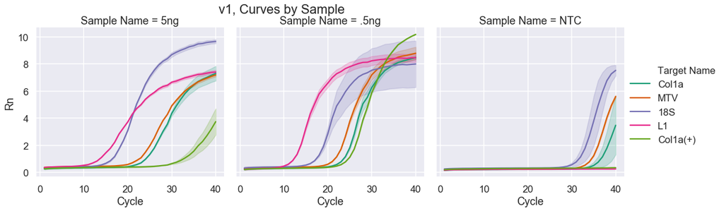

```python
g.fig
```

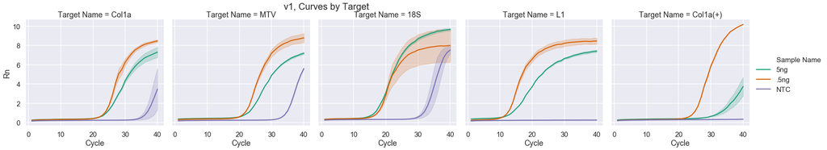

```python
g.fig
```

## Pilot of gene standard curve, quantitative

```python
grp
```

| Target Name | Sample Name | Ct_clean gstd | Ct_clean mean |
| --- | --- | --- | --- |
| 18S | .5ng | 1.03 | 18.58 |
|  | 5ng | 1.00 | 17.83 |
|  | NTC | 1.06 | 33.05 |
| Col1a | .5ng | 1.01 | 21.65 |
|  | 5ng | 1.00 | 21.85 |
|  | NTC | 1.08 | 35.26 |
| Col1a(+) | .5ng | 1.00 | 25.30 |
|  | 5ng | 1.06 | 34.68 |
|  | NTC | NaN | NaN |
| L1 | .5ng | 1.01 | 12.75 |
|  | 5ng | 1.00 | 15.09 |
|  | NTC | NaN | NaN |
| MTV | .5ng | 1.01 | 22.48 |
|  | 5ng | 1.00 | 24.01 |
|  | NTC | 1.00 | 34.99 |

# Nuclei and nanograms

- our reference template is extracted genomic DNA of a knowable ng/ul
- the # of nuclei in each is approximately:
  - n ng DNA *(1000 pg/1 ng)* (1 nuclei/6pg) = # nuclei
- this can be inverted

```python
# wrapper functions for nuclei <-> ng conversions
def ng_to_nuclei(ng):
    return ng * 1000 / 6
def nuclei_to_ng(nuclei):
    return  nuclei * 6 /1000
```

## punch sizes and nuclei

```python
#measurements with standard ruler, waiting on caliper batteries
tipDict = {
    "P1000": 1.1,
    "P300": 1,
    "P20": .75,
    "P10": .6
}

# visual inspection of images, likely order of magnitude correct
area_umSq = 10000 #measured with Fiji
nuclei = 25 #hand counted, not accounting for z stacking
density = nuclei / area_umSq #math
```

```python
punch = pd.DataFrame.from_dict(tipDict, orient="index",
                               columns=['diam_mm']).reset_index().rename(
                                   {"index": "template"},
                                   axis=1)  #convert to dataframe + clean up
punch['area_mm_sq'] = punch['diam_mm'].apply(
    lambda diam: np.pi * np.square(diam / 2))
punch['area_uM_sq'] = punch['area_mm_sq'] * np.square(
    1000)  #important to do *squared* dimensional analysis
punch['total_nuclei'] = punch['area_uM_sq'] * density
punch['ng'] = punch.total_nuclei.apply(nuclei_to_ng)
templates = {'High(5ng)': 5, 'Low(0.5ng)': .5, 'NTC': 0}
temp = pd.DataFrame.from_dict(templates, orient="index",
                              columns=['ng']).reset_index().rename(
                                  {"index": "template"}, axis=1)
temp['total_nuclei'] = temp.ng.apply(ng_to_nuclei)
templates = punch.append(temp, sort = False)
```

## calculated approximations

```python
templates.round(2) # ball park estimates for comparing to later data
```

|  | template | diam_mm | area_mm_sq | area_uM_sq | total_nuclei | ng |
| --- | --- | --- | --- | --- | --- | --- |
| 0 | P1000 | 1.10 | 0.95 | 950331.78 | 2375.83 | 14.25 |
| 1 | P300 | 1.00 | 0.79 | 785398.16 | 1963.50 | 11.78 |
| 2 | P20 | 0.75 | 0.44 | 441786.47 | 1104.47 | 6.63 |
| 3 | P10 | 0.60 | 0.28 | 282743.34 | 706.86 | 4.24 |
| 0 | High(5ng) | NaN | NaN | NaN | 833.33 | 5.00 |
| 1 | Low(0.5ng) | NaN | NaN | NaN | 83.33 | 0.50 |
| 2 | NTC | NaN | NaN | NaN | 0.00 | 0.00 |

# v3: standard curves of gel punches x primers, for amplicons represented in the genome at ~standard curve amounts

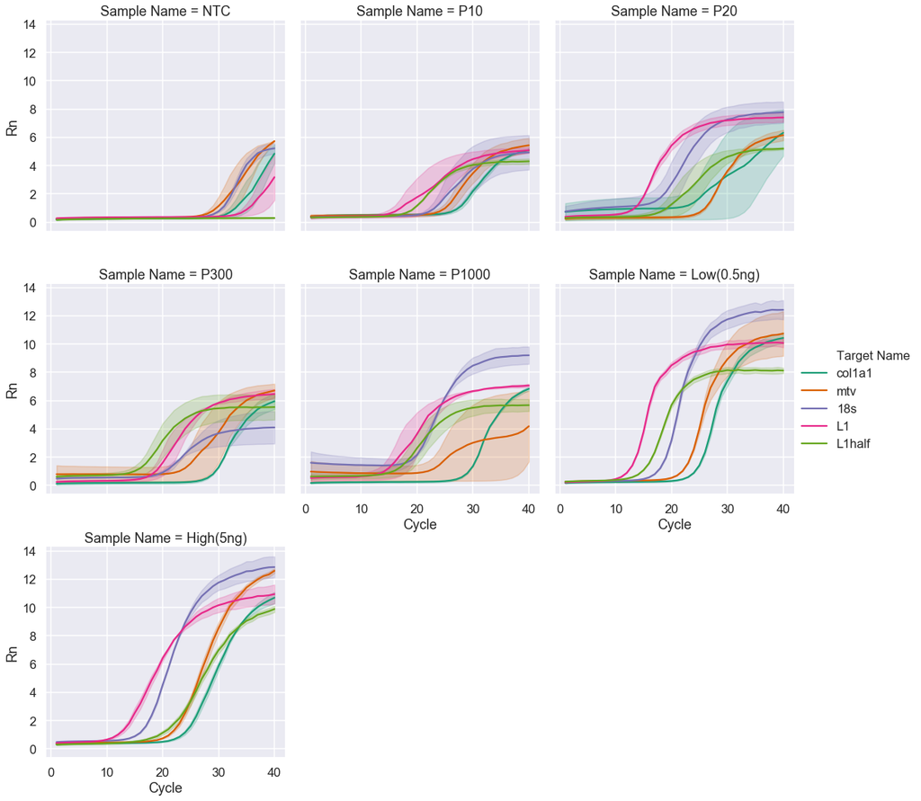

```python
g.fig
```

## gDNA template issues

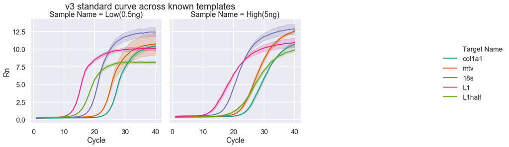

```python
g.fig
```

## !: Order of magnitude differences are not represented in gDNA templates

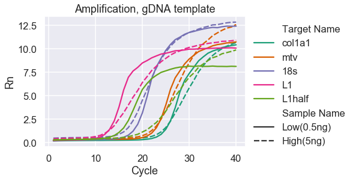

```python
fig
```

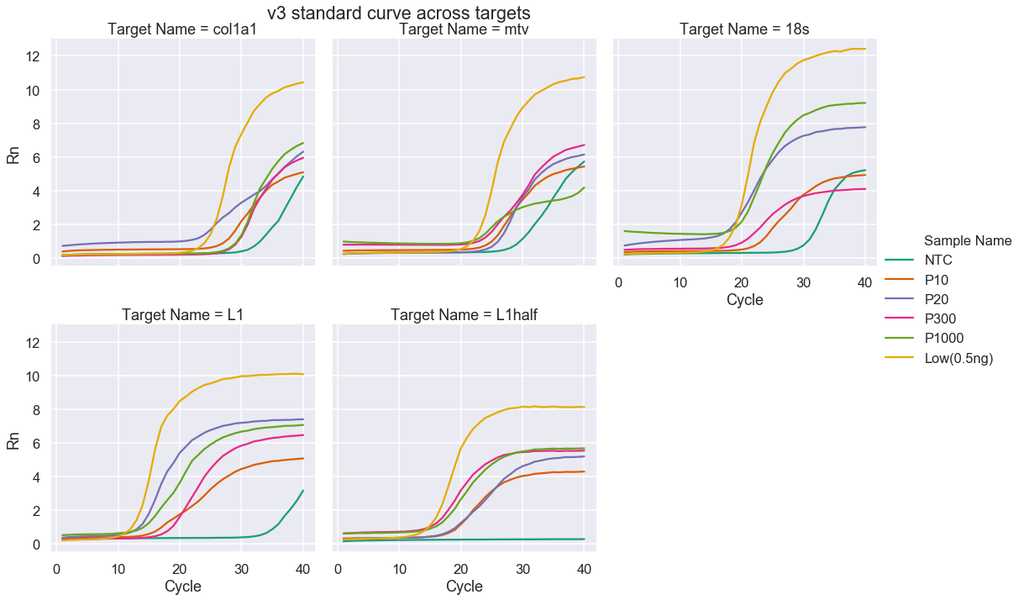

```python
g.fig
```

# DIY standard curve

```python
#dict for approximate values
genome_copies = {
    "col1a1": 2,
    "mtv": 10,
    "18s": 100,
    "L1": 3000,
    "L1half": 1500
}
```

```python
d['num_amplicons_calc'] = d['total_nuclei_calc']*d['genomeCopies']
d['log2_num_amplicons_calc'] = np.log2(d['num_amplicons_calc'].replace(0, np.nan)).fillna(0)
d.tail()[['Well', 'SampleName', 'Target Name', 'Ct_clean', 'genomeCopies', 'num_amplicons_calc', 'log2_num_amplicons_calc']]
```

|  | Well | SampleName | Target Name | Ct_clean | genomeCopies | num_amplicons_calc | log2_num_amplicons_calc |
| --- | --- | --- | --- | --- | --- | --- | --- |
| 65 | H8 | High(5ng) | L1half | 20.104107 | 1500 | 1.250000e+06 | 20.253497 |
| 66 | H9 | High(5ng) | L1 | 9.643442 | 3000 | 2.500000e+06 | 21.253497 |
| 67 | H10 | High(5ng) | 18s | 15.661564 | 100 | 8.333333e+04 | 16.346606 |
| 68 | H11 | High(5ng) | mtv | 19.537718 | 10 | 8.333333e+03 | 13.024678 |
| 69 | H12 | High(5ng) | col1a1 | 23.596674 | 2 | 1.666667e+03 | 10.702750 |

## Linear regression to standards

```python
stds = d.query('SampleName.str.contains("Low")')

x = stds['log2_num_amplicons_calc']
y = stds['Ct_clean']
y_range = [y.min().round(2), y.max().round()]

m, b, r_value, p_value, std_err = stats.linregress(x, y)
ct_line = m*x + b
line_eq = "y={:.2f}x+{:.2f}".format(m, b)

# considering range, not really interested in working  too far outside our range
is_ranged = d['Ct_clean'].between(y.min(), y.max())
ranged = d[is_ranged].copy()
ranged['log2_num_amplicons_curveExp'] = (ranged['Ct_clean'] - b) / m
ranged['num_amplicons_curveExp'] = np.exp2(ranged['log2_num_amplicons_curveExp'])
```

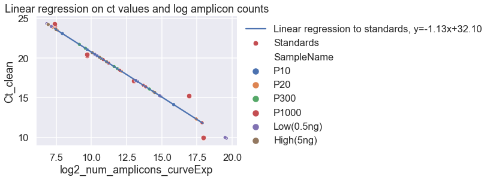

```python
fig
```

# correlation between calculated + 'empirical'

```python
# modeling correlation between calculated and emperical
x= 'log2_num_amplicons_calc'
y= 'log2_num_amplicons_curveExp'
m, b, r_value, p_value, std_err = stats.linregress(ranged[x], ranged[y])
ct_line = m*ranged[x] + b
line_eq = "y={:.2f}x+{:.2f}".format(m, b)
```

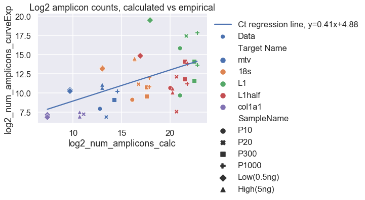

```python
fig
```

## distribution across sizes

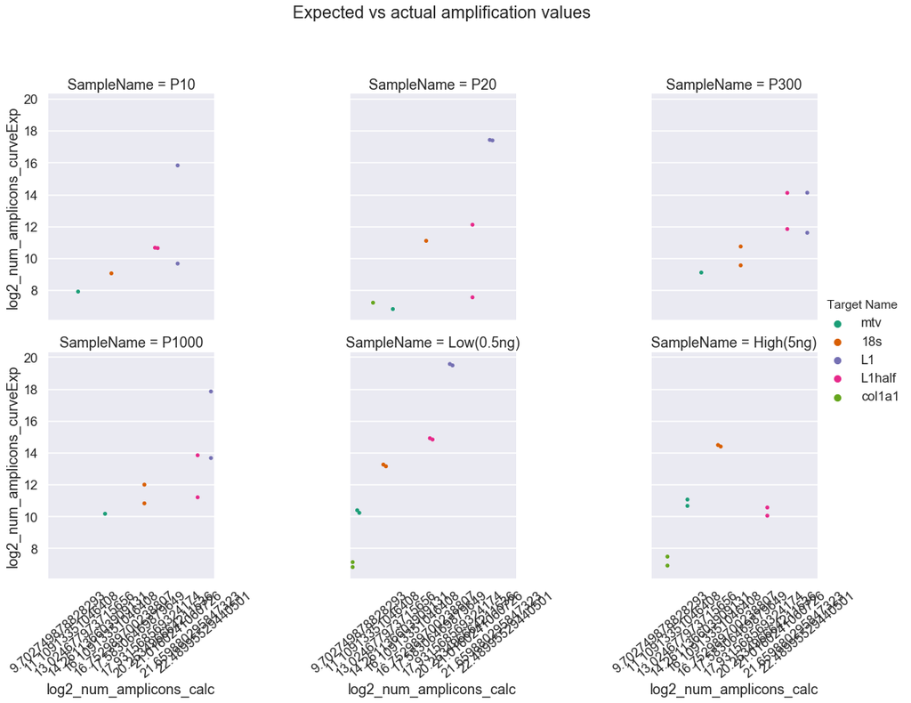

```python
# terrible figure axes
g.fig
```